# Multiscale Analysis of Forest Cover

Walkthrough by Michael France Nelson

Continuation of my opinionated walkthrough. I’m going to use sf for vector data in part 3

# 1 Data Import

## 1.1 NLCD data

```r
# sf doesn't seem to like `.adf` files
# nlcd = st_read(paste0(book_data, "nlcd2011SE/"))

# and this isn't working...
# nlcd = st_as_sf(raster(paste0(book_data, "nlcd2011SE")))

# use raster for now
nlcd = raster(paste0(book_data, "nlcd2011SE"))
```

## 1.2 Sites vector data

Reading with `st_read` is less finnicky than `readOGR`

```r
sites = st_read(paste0(book_data, "reptiledata"))
st_crs(sites) = proj4string(nlcd)
```

You can use `subset` on `sf` objects: See my comments in part 2 about matching ‘corn’ in the management field.

Normally I don’t like to overwrite variables.  
It’s a tradeoff between unintentional changes (overwriting), and cluttering up the workspace with unused variables (creating new variables).

```r
grepl("corn", sites$management, ignore.case = TRUE)
```

```
##  [1] FALSE FALSE FALSE FALSE FALSE FALSE FALSE FALSE FALSE FALSE FALSE FALSE
## [13] FALSE FALSE FALSE FALSE FALSE FALSE FALSE  TRUE  TRUE FALSE FALSE FALSE
## [25] FALSE FALSE FALSE FALSE FALSE FALSE FALSE FALSE FALSE FALSE FALSE FALSE
## [37] FALSE FALSE FALSE FALSE FALSE FALSE FALSE FALSE FALSE FALSE FALSE  TRUE
## [49]  TRUE FALSE FALSE FALSE FALSE FALSE FALSE FALSE FALSE FALSE FALSE FALSE
## [61] FALSE FALSE FALSE FALSE FALSE FALSE FALSE FALSE FALSE  TRUE  TRUE FALSE
## [73] FALSE FALSE FALSE  TRUE FALSE FALSE FALSE FALSE FALSE FALSE FALSE FALSE
## [85] FALSE
```

```r
sites = subset(sites, !grepl("corn", sites$management, ignore.case = TRUE))
```

## 1.3 Forest mask

Factoring the entire raster takes about 22 seconds on my computer. It’s easy to see how long a process takes with `system.time()`. Use curly braces around the code you want to run. You don’t really have to factor the raster at all, though.  
It’s probably easier to work with the values directly.

```r
system.time({nlcd_f = as.factor(nlcd)})
```

[output not shown]

# 2 Buffer sample sites

A custom buffer function makes creating the raster with buffer much easier: `spgeom` is the spatial object we want to buffer `rast` is the raster we want to crop to the buffered size `dist` is the width of the buffer

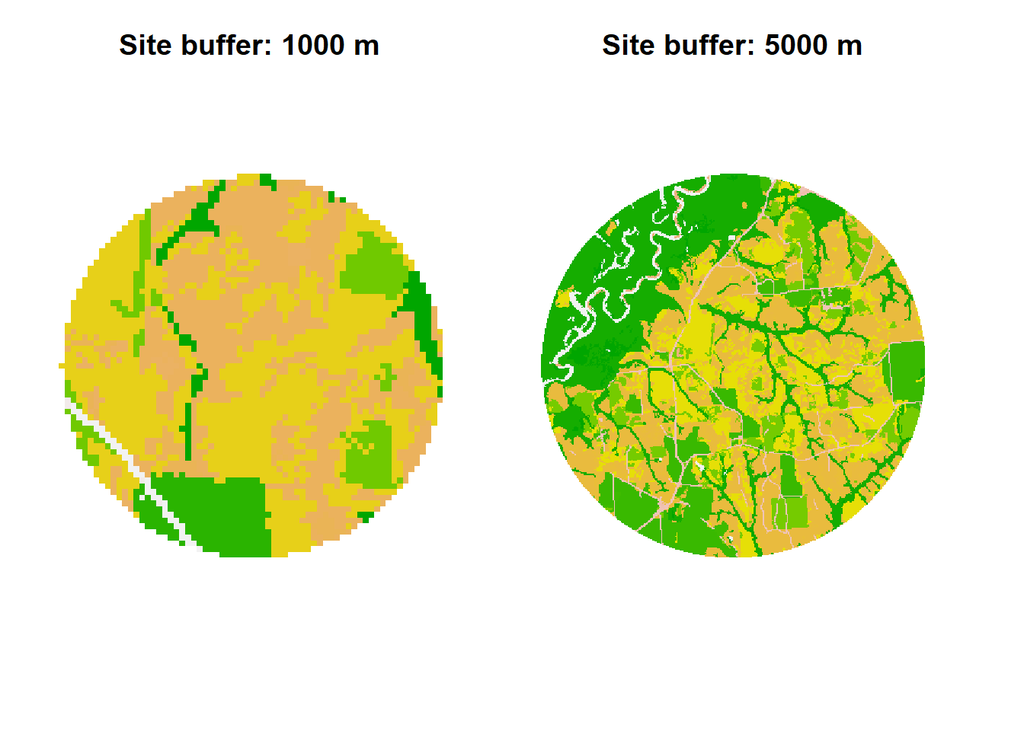

```r
raster_buffer_site = function(rast, spgeom, dist)
{
  sp1 = st_buffer(spgeom, dist = dist)
  crp = crop(rast, sp1)
  return(mask(crp, sp1))
}

b1 = 1e3
b2 = 5e3
{
  par(
    mfrow = c(1, 2),
    mar = c(1, 1, 1, 1),
    oma = c(1, 1, 1, 1))
  plot(
    raster_buffer_site(nlcd, sites[1, ], b1),
    axes = F, box = F, legend = F,
    main = paste0("Site buffer: ", b1, " m"))
  plot(
    raster_buffer_site(nlcd, sites[1, ], b2),
    axes = F, box = F, legend = F,
    main = paste0("Site buffer: ", b2, " m"))
}
```

# 3 Classify habitat/non habitat

It’s not necessary to classify habitat/non-habitat yet. Making a mask of the whole raster is time-consuming, and it commits us to a particular habitat/non-habitat classification scheme early in the process.

Since specifying habitat/non-habitat will be useful we can make a more flexible function so we can specify which cover classes are habitat.

```r
habitat_mask = function(rast, habitat_codes)
{
  mask_out = rast * 0
  mask_out[rast[] %in% habitat_codes] = 1
  return(mask_out)
}
```

The `%in%` operator is an easy way to test whether any elements of a vector are present in a colleciton of values. It is a pretty quick way to build a mask in this case. Using the square brackets with a raster is a shortcut to retrieve its values as a vector.

# 4 Habitat/non-habitat areas

The book makes some conversion factors to use on intermediate quantities, but it’s easier to work with cell counts and do any necessary conversions at the end.

We can wrap it up into a big function that returns lots of relevant stuff:

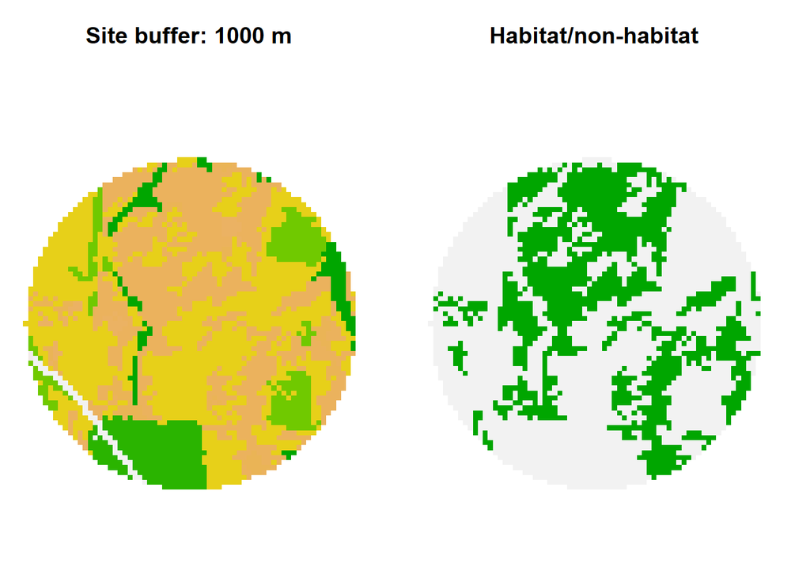

```r
hab_stats = function(rast, spgeom, dist, hab_codes)
{
  site = raster_buffer_site(rast, spgeom, dist)
  hab = habitat_mask(site, hab_codes)
  n_cells_buffer = ncell(hab) - sum(is.na(hab)[])
  n_cells_hab    = sum(hab[] == 1, na.rm = T)
  return(list(
    site_buffer = site,
    habitat_buffer = hab,
    prop_hab = n_cells_hab / n_cells_buffer,
    n_habitat = n_cells_hab,
    n_buffer = n_cells_buffer))
}

i = 1
hab_i = hab_stats(nlcd, sites[i, ], b1, c(41, 42, 43))
{
  par(mfrow = c(1, 2), oma = c(0, 0, 0, 0), mar = c(0, 1, 3, 0))
  plot(
    hab_i$site_buffer,
    axes = F, legend = F, box = F,
    main = paste0("Site buffer: ", b1, " m"))
  plot(
    hab_i$habitat_buffer,
    axes = F, legend = F, box = F,
    main = "Habitat/non-habitat")
}
```

```r
hab_i$prop_hab
```

```
## [1] 0.360745
```

# 5 Charactistic size: buffers

```r
buffers = c(1e2, 5e2, 1e3, 2e3, 3e3, 4e3)
dat = data.frame(site = 1:nrow(sites))

system.time(
  {
    for (b in buffers[-1])
    {
      pct_i = c()
      for (i in 1:nrow(sites))
      {
        h_i = hab_stats(nlcd, sites[i, ], b, c(41, 42, 43))
        pct_i = c(pct_i, h_i$prop_hab)
      }
      dat = cbind(dat, pct_i)
    }
  }
)
```

```
##    user  system elapsed
##   40.22    0.64   41.03
```

```r
names(dat) = paste0("", buffers, " m")
```

Package `psych` has a nice pair plotting function:

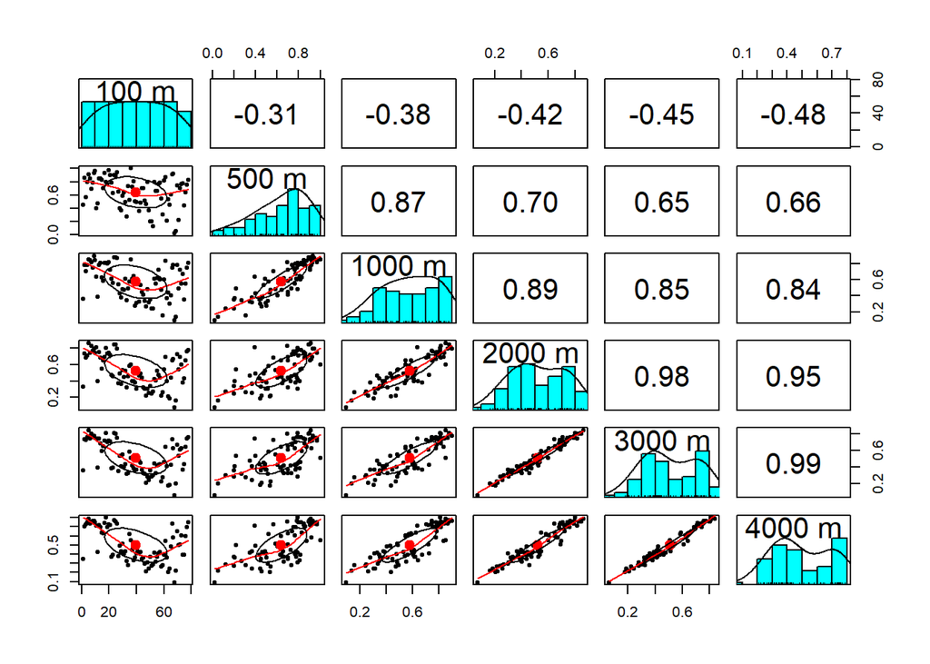

```r
psych::pairs.panels(dat)
```